# Rendimiento y riesgo

Diego Lozoya

2025-02-11

Ya sabemos que los cambios en el precio tienen un comportamiento dado por la EDE

$$ds=S\mu dt+S\sigma dW$$

Los valores de los parámetros $\mu, \sigma$ dependen del tiempo, por lo que debemos definir si serán diarios, anualizados o que características vamos a considerar.

```r
library(quantmod)
library(lubridate)
clave <- "GFNORTEO.MX"
datos <- new.env()

getSymbols(clave, from="2000-01-02", to=today(), env=datos)
```

```
## [1] "GFNORTEO.MX"
```

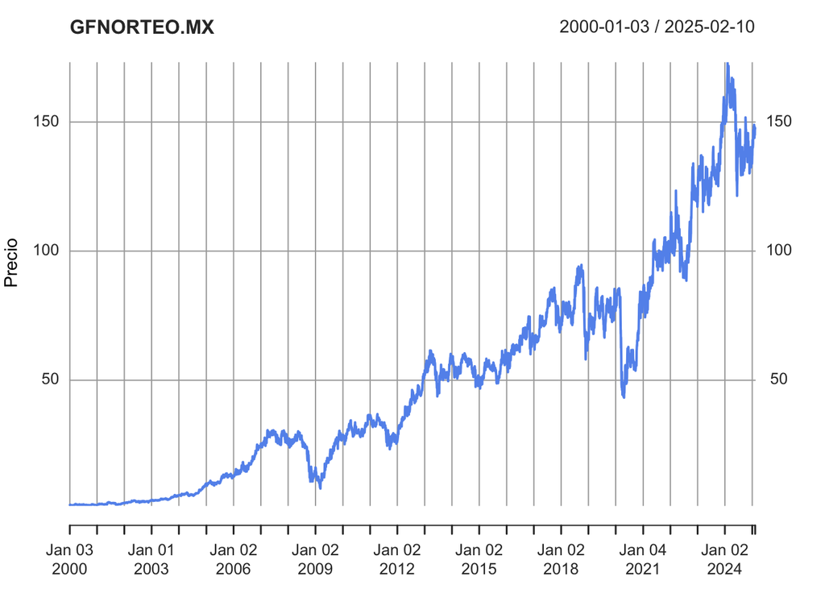

```r
precio <- datos[[clave]][,6]

plot(precio, type="l", ylab="Precio", col="cornflowerblue", main=clave)
```

Nuestro análisis es sobre el rendimiento

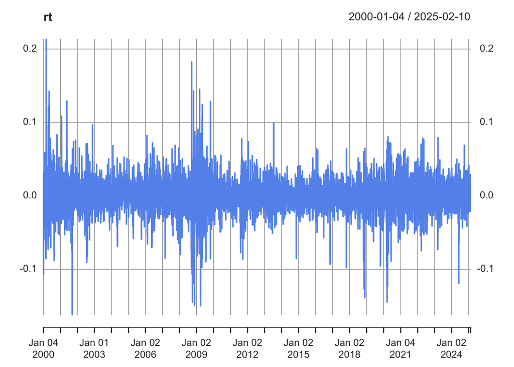

```r
rt <- na.omit(diff(log(precio)))
plot(rt, col="cornflowerblue")
```

Deciamos que los parámetros dependen del tiempo, primero consideramos los datos históricos, es decir todos los que existen.

```r
mu_di_hist <- mean(rt)
sigma_di_hist <- sd(rt)

mu_di_hist
```

```
## [1] 0.0006874502
```

```r
sigma_di_hist
```

```
## [1] 0.02301177
```

Estos parámetros podemos anualizarlos para que tengan una mejor interprectación

```r
mu_anual_hist <- mu_di_hist*252
mu_anual_hist
```

```
## [1] 0.1732375
```

```r
sigma_anual_hist <- sigma_di_hist*sqrt(252)
sigma_anual_hist
```

```
## [1] 0.3653005
```

Vamos a calcular estos mismos parámetros, para cada uno de los años de información que tenemos

```r
library(dplyr)
names(rt) <- "rend"
tabla <- rt %>%
  as_tibble() %>%
  mutate(year=year(rt)) %>%
  group_by(year) %>%
  summarise("Ren_diario"=mean(rend),
            "Vol_diaria"=sd(rend),
            "Ren_anual"=mean(rend)*252,
            "Vol_anual"=sd(rend)*sqrt(252))
```

Hasta ahora hemos considerado que los rendimientos tienen el supuesto de normalidas, esto sucede porque los rendimientos se explican por un proceso estocástico que está determinado por un epsilon $\epsilon \sim N(0,1$

Veamos el histograma del rendimiento.

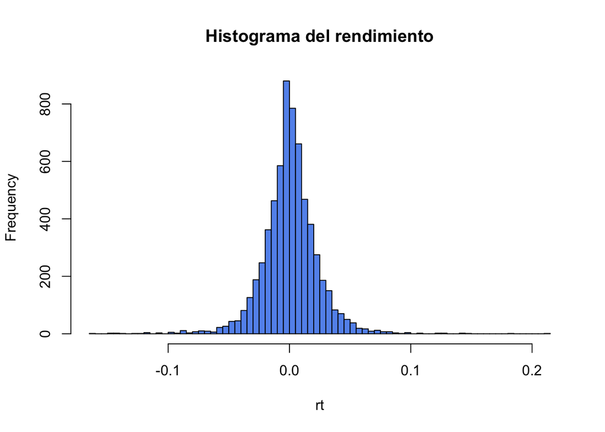

```r
hist(rt, n=100, col="cornflowerblue", main="Histograma del rendimiento")
```

Vamos a efectuar una prueba formal de NORMALIDAD. Una prueba formal nos indica si estrctamente la variable sigue o no el comportamiento deseado. En este caso, la prueba que usaremos se llama Jarque-Bera y consiste en una prueba de hipótesis, con una nula y otra alternativa y usamos el valor del p-value para decidir

*Nota:* Para mi proyecto tercera entrega será necesario que haga una prueba de normalidad, entonces debo investigar que es la prueba, que características tiene y toda la información relevante

$H_0:$ Hay normalidad en los datos $H_1$: No hay normalidad en los datos

```r
library(moments)
jarque.test(as.numeric(rt))
```

```
##
##  Jarque-Bera Normality Test
##
## data:  as.numeric(rt)
## JB = 11885, p-value < 2.2e-16
## alternative hypothesis: greater
```

*P-value*: Probabilidad de comoter error tipo I (rechazo $H_0$ cuando es verdadera)

Ya que P-value $\approx$ 0 se rechaza $H_0$. No hay información suficiente para aceptar la normalidad de los datos (no se distribuyen normalmente). Por convencionalidad, asumimos que los rendimientos si son normales, ya que es la distribución a la que más se parece.

¿Por qué? Porque presentan leptocurtosis, es decir un exceso de curtosis respecto a lo que es normal.

Esta prueba compara la distribución de lo datos con los de una normal. La normal tiene 2 características: - sesgo 0 - curtosis 3

```r
skewness(rt)
```

```
##       rend
## -0.0217307
```

```r
kurtosis(rt)
```

```
##    rend
## 9.69002
```

Comprobando esto con los precios:

```r
jarque.test(as.numeric(precio))
```

```
##
##  Jarque-Bera Normality Test
##
## data:  as.numeric(precio)
## JB = 730.43, p-value < 2.2e-16
## alternative hypothesis: greater
```

Los precios de un activo no se distribuyen normalmente.

Ahora hagamos la prueba de rendimiento diario promedio igual a 0:

$H_0:$ La media del rendimiento diario es igual a 0 $H_1$: La media del rendimiento diario es diferente a 0

```r
t.test(as.numeric(rt), mu=0, alternative = "two.sided")
```

```
##
##  One Sample t-test
##
## data:  as.numeric(rt)
## t = 2.3849, df = 6372, p-value = 0.01711
## alternative hypothesis: true mean is not equal to 0
## 95 percent confidence interval:
##  0.000122372 0.001252528
## sample estimates:
##    mean of x
## 0.0006874502
```

P-value = 0.01711. Dependiendo del nivel de significancia se aceptaría o rechazaría $H_0$.

La media verdadera no es estadísticamente igual a 0 con un nivel de confianza del 95%

La media verdadera es estadísticamente igual a 0 con un nivel de confianza del 99%